# Time Series: A First Course with Bootstrap Starter

# Lesson 8-4: Time Series Entropy

- We now extend the concept of entropy to time series.
- We also define conditional entropy.

## Definition 8.4.1.

The **entropy rate** of a strictly stationary time series $\{ X_t \}$ is
$$h_X = \lim_{n \rightarrow \infty} n^{-1} H (\underline{X}),$$
where $\underline{X} = [ X_1, \ldots, X_n]$.

## Example 8.4.2. Gaussian Entropy Rate

- We determine the entropy rate for a stationary Gaussian time series with mean zero and spectral density $f$.
- Using Theorem 6.4.5,
  $$\det \Gamma_n \approx \det \Lambda = \prod_{\ell = [n/2]-n+1}^{[n/2]}
  f(\lambda_{\ell}).$$
- Taking logs and using Riemann sums, we obtain
  $$h_X = .5 \left( 1 + \log (2 \pi) + {(2 \pi)}^{-1} \int_{-\pi}^{\pi} \log
  f(\lambda) \, d\lambda \right).$$

## Definition 8.4.5. Conditional Entropy

- The conditional entropy of $X$ given $\underline{Z}$ is
  $$H(X \vert \underline{Z}) = - {\mathbb E} [ \log p_{X \vert
  \underline{Z}} (X \vert \underline{Z}) ].$$
- Conditioning always lowers entropy: $H(X \vert \underline{Z}) \leq H (X)$.
- More information means that future outcomes are less uncertain.

## Proposition 8.4.8.

- The entropy rate of a strictly stationary time series $\{ X_t \}$ is
  $$h_X = H ( X_0 \vert X_{-1}, X_{-2}, \ldots).$$
- This is the entropy of $X_0$ conditional on its infinite past.

## Exercise 8.29. Entropy of a Gaussian AR(1).

- We compute the entropy for a sample of an AR(1), and compare to the entropy rate.

```r
gauss.ent.ar1 <- function(phi,sig2,n)
{
    Sigma <- toeplitz(phi^(seq(0,n-1,length=n))*sig2/(1-phi^2))
    ent <- n/2*(1 + log(2*pi)) + log(det(Sigma))/2
    return(ent)
}
```

- We consider an AR(1) with $\phi = .9$ and variance $1$. So $\sigma^2 = 1- \phi^2$, and the entropy rate is $.5 ( 1 + \log (2 \pi) + \log \sigma^2)$.
- We plot the entropy divided by $n$.

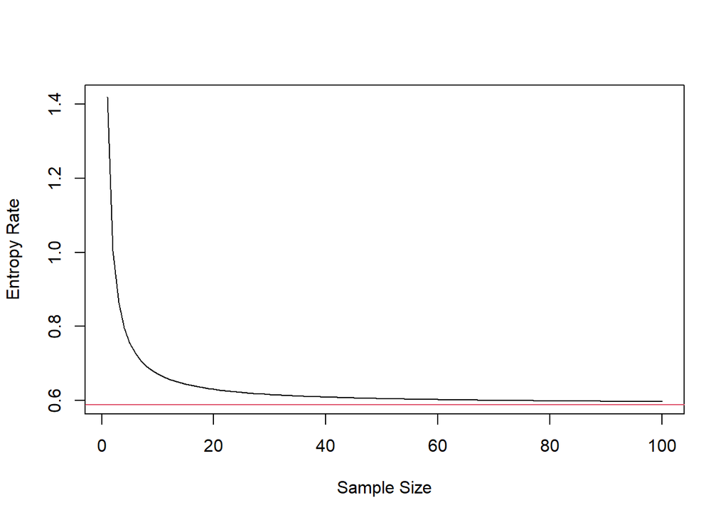

```r
phi <- .9
sig2 <- 1-phi^2
ent.rate <- .5*(1 + log(2*pi) + log(sig2))
ents <- NULL
for(n in 1:100)
{
    ents <- c(ents,gauss.ent.ar1(phi,sig2,n))
}
plot(ts(ents/seq(1,100)),xlab="Sample Size",ylab="Entropy Rate")
abline(h = ent.rate,col=2)
```